# shinkansenTrain_v08_To_TDI_Final

## **Passenger Satisfaction Prediction**

### **Context**

This problem statement is based on the Shinkansen Bullet Train in Japan, and passengers’ experience with that mode of travel. This machine-learning exercise aims to determine the relative importance of each parameter with regard to their contribution to the passengers’ overall travel experience.

### **Goal**

The goal of the problem is to **predict whether a passenger was satisfied or not** considering his/her overall experience of traveling on the Shinkansen Bullet Train. We would also like to understand which parameters play an important role in swaying passenger feedback towards a positive scale.

### **DataSet**

The dataset contains a random sample of individuals who travelled on this train. There are two datasets for this problem: **Travel data** and **Survey data**.

- **Travel data**: Information related to passengers and attributes related to the Shinkansen train, in which they traveled.
- **Survey data**: Aggregated data of surveys indicating the post-service experience including their "Overall Experience". (Passengers were later asked to provide their feedback on various parameters related to the travel along with their overall experience.)

#### **Data Description**

- **ID** - The unique ID of the passenger
- **Gender** - The gender of the passenger: "Male", "Female"
- **Customer_Type** - Loyalty type of the passenger: "Loyal Customer" , "Disloyal Customer"
- **Age** - The age of the passenger
- **Type_Travel** - Purpose of travel for the passenger: "Personal Travel", "Business Travel"
- **Travel_Class** - The train class that the passenger traveled in: "Business", "Eco"
- **Travel_Distance** - The distance traveled by the passenger
- **Departure_Delay_in_Mins** - The delay (in minutes) in train departure
- **Arrival_Delay_in_Mins** - The delay (in minutes) in train arrival

### Importing the required libraries

```python
import pandas as pd
import numpy as np
import matplotlib.pyplot as plt
import seaborn as sns
import random


# To scale the data using z-score

from sklearn.model_selection import train_test_split

# Algorithms to use
from sklearn.linear_model import LogisticRegression

from sklearn.svm import SVC
from sklearn.tree import DecisionTreeClassifier
from sklearn.ensemble import BaggingClassifier
from sklearn.ensemble import RandomForestClassifier

import xgboost as xgb

# Metrics to evaluate the model
from sklearn import metrics
from sklearn.metrics import accuracy_score, confusion_matrix, classification_report, precision_recall_curve,recall_score
from sklearn import tree
from sklearn.preprocessing import MinMaxScaler, LabelEncoder, OneHotEncoder


import tensorflow as tf
from tensorflow.keras.models import Sequential
from tensorflow.keras.layers import Dense, Dropout, Activation, BatchNormalization, Input
from tensorflow.keras import backend


# For tuning the model
from sklearn.model_selection import GridSearchCV

# To ignore warnings
import warnings
warnings.filterwarnings("ignore")
```

```python
from google.colab import drive
drive.mount('/content/drive')
```

### **Loading The Data**

```python
###### Reading Data From Local Disk
# travel_data = pd.read_csv("Traveldata_train.csv")
# survey_data = pd.read_csv("Surveydata_train.csv")

###### Reading Data From Google Drive
travel_data = pd.read_csv("/content/drive/MyDrive/MIT_ML/Hackathon/Traveldata_train.csv")
survey_data = pd.read_csv("/content/drive/MyDrive/MIT_ML/Hackathon/Surveydata_train.csv")
```

### **Merging Travel and Survey Datasets**

```python
data = pd.merge(travel_data, survey_data, on='ID')
```

## **An Overview of the Dataset**

```python
data.head()
```

|  | ID | Gender | Customer_Type | Age | Type_Travel | Travel_Class | Travel_Distance | Departure_Delay_in_Mins | Arrival_Delay_in_Mins | Overall_Experience | ... | Onboard_Wifi_Service | Onboard_Entertainment | Online_Support | Ease_of_Online_Booking | Onboard_Service | Legroom | Baggage_Handling | CheckIn_Service | Cleanliness | Online_Boarding |
| --- | --- | --- | --- | --- | --- | --- | --- | --- | --- | --- | --- | --- | --- | --- | --- | --- | --- | --- | --- | --- | --- |
| 0 | 98800001 | Female | Loyal Customer | 52.0 | NaN | Business | 272 | 0.0 | 5.0 | 0 | ... | Good | Needs Improvement | Acceptable | Needs Improvement | Needs Improvement | Acceptable | Needs Improvement | Good | Needs Improvement | Poor |
| 1 | 98800002 | Male | Loyal Customer | 48.0 | Personal Travel | Eco | 2200 | 9.0 | 0.0 | 0 | ... | Good | Poor | Good | Good | Excellent | Needs Improvement | Poor | Needs Improvement | Good | Good |
| 2 | 98800003 | Female | Loyal Customer | 43.0 | Business Travel | Business | 1061 | 77.0 | 119.0 | 1 | ... | Needs Improvement | Good | Excellent | Excellent | Excellent | Excellent | Excellent | Good | Excellent | Excellent |
| 3 | 98800004 | Female | Loyal Customer | 44.0 | Business Travel | Business | 780 | 13.0 | 18.0 | 0 | ... | Acceptable | Needs Improvement | Acceptable | Acceptable | Acceptable | Acceptable | Acceptable | Good | Acceptable | Acceptable |
| 4 | 98800005 | Female | Loyal Customer | 50.0 | Business Travel | Business | 1981 | 0.0 | 0.0 | 1 | ... | Needs Improvement | Good | Excellent | Good | Good | Good | Good | Good | Good | Good |

5 rows × 25 columns

```python
data.info()
```

```
<class 'pandas.core.frame.DataFrame'>
Int64Index: 94379 entries, 0 to 94378
Data columns (total 25 columns):
 #   Column                   Non-Null Count  Dtype
---  ------                   --------------  -----
 0   ID                       94379 non-null  int64
 1   Gender                   94302 non-null  object
 2   Customer_Type            85428 non-null  object
 3   Age                      94346 non-null  float64
 4   Type_Travel              85153 non-null  object
 5   Travel_Class             94379 non-null  object
 6   Travel_Distance          94379 non-null  int64
 7   Departure_Delay_in_Mins  94322 non-null  float64
 8   Arrival_Delay_in_Mins    94022 non-null  float64
 9   Overall_Experience       94379 non-null  int64
```

[output cut: 17 more lines]

```python
# Counting the number of missing values in each column
data.isna().sum()
```

```
ID                            0
Gender                       77
Customer_Type              8951
Age                          33
Type_Travel                9226
Travel_Class                  0
Travel_Distance               0
Departure_Delay_in_Mins      57
Arrival_Delay_in_Mins       357
Overall_Experience            0
Seat_Comfort                 61
Seat_Class                    0
Arrival_Time_Convenient    8930
Catering                   8741
Platform_Location            30
Onboard_Wifi_Service         30
Onboard_Entertainment        18
Online_Support               91
Ease_of_Online_Booking       73
Onboard_Service            7601
Legroom                      90
Baggage_Handling            142
CheckIn_Service              77
Cleanliness                   6
Online_Boarding               6
dtype: int64
```

**Observations:**

```python
# Counting the number of rows that have missing values
(data.isna().sum(axis=1)>0).sum()
```

```
38876
```

```python
# Check the numberr of unique values in each column
data.nunique()
```

```
ID                         94379
Gender                         2
Customer_Type                  2
Age                           75
Type_Travel                    2
Travel_Class                   2
Travel_Distance             5210
Departure_Delay_in_Mins      437
Arrival_Delay_in_Mins        434
Overall_Experience             2
Seat_Comfort                   6
Seat_Class                     2
Arrival_Time_Convenient        6
Catering                       6
Platform_Location              6
Onboard_Wifi_Service           6
Onboard_Entertainment          6
Online_Support                 6
Ease_of_Online_Booking         6
Onboard_Service                6
Legroom                        6
Baggage_Handling               5
CheckIn_Service                6
Cleanliness                    6
Online_Boarding                6
dtype: int64
```

```python
# Count the number of duplicated rows
data.duplicated().sum()
```

```
0
```

```python
# Checking summary statistics
data.describe().T
```

|  | count | mean | std | min | 25% | 50% | 75% | max |
| --- | --- | --- | --- | --- | --- | --- | --- | --- |
| ID | 94379.0 | 9.884719e+07 | 27245.014865 | 98800001.0 | 98823595.5 | 98847190.0 | 98870784.5 | 98894379.0 |
| Age | 94346.0 | 3.941965e+01 | 15.116632 | 7.0 | 27.0 | 40.0 | 51.0 | 85.0 |
| Travel_Distance | 94379.0 | 1.978888e+03 | 1027.961019 | 50.0 | 1359.0 | 1923.0 | 2538.0 | 6951.0 |
| Departure_Delay_in_Mins | 94322.0 | 1.464709e+01 | 38.138781 | 0.0 | 0.0 | 0.0 | 12.0 | 1592.0 |
| Arrival_Delay_in_Mins | 94022.0 | 1.500522e+01 | 38.439409 | 0.0 | 0.0 | 0.0 | 13.0 | 1584.0 |
| Overall_Experience | 94379.0 | 5.466576e-01 | 0.497821 | 0.0 | 0.0 | 1.0 | 1.0 | 1.0 |

## **EDA**

### **Univariate Analysis**

```python
# Function to plot the boxplot and histogram of a feature

def histogram_boxplot(data, feature, figsize=(10, 5), kde=False):

    f2, (ax_boxplot, ax_hist) = plt.subplots(
        nrows = 2,      # Number of rows of the subplot
        sharex = True,  # x-axis will be shared among the two subplots
        gridspec_kw = {"height_ratios": (0.2, 0.8)},
        figsize = figsize,
    )

    # the mean value of the column is displayed using a star
    sns.boxplot(data=data, x=feature, ax=ax_boxplot, showmeans=True, color="lightgreen")

    # Histogram
    sns.histplot(data=data, x=feature, kde=kde, ax=ax_hist)

    # show mean with a green dotted line
    ax_hist.axvline(data[feature].mean(), color="green", linestyle="--")

    # show median with a black solid line
    ax_hist.axvline(data[feature].median(), color="black", linestyle="-")
```

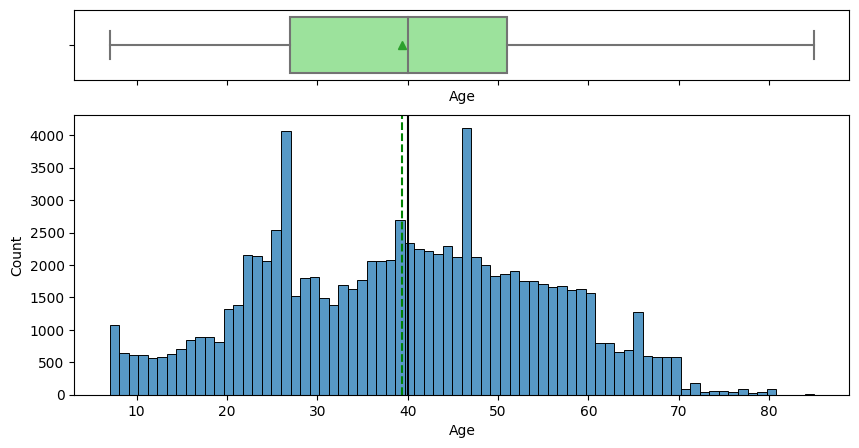

```python
histogram_boxplot(data, "Age")
```

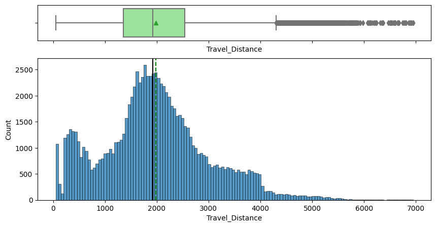

```python
histogram_boxplot(data, 'Travel_Distance')
```

```python
# Function to plot labeled barplots

def labeled_barplot(data, feature):

    # create a new figure that has a width proportional to the number of bars that we want to show
    plt.figure(figsize=(data[feature].nunique() + 1, 5))

    plt.xticks(rotation = 90)

    ax = sns.countplot(
        data = data,
        x = feature,
        palette = "Paired",
        order = data[feature].value_counts().index[:].sort_values(),
    )

    for patch in ax.patches:

        x = patch.get_x() + patch.get_width() / 2
        y = patch.get_height()

        ax.text(x, y, y, ha='center', va='bottom')

    plt.show()  # show the plot
```

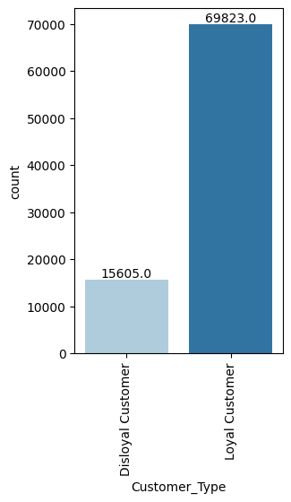

```python
labeled_barplot(data, 'Customer_Type')
```

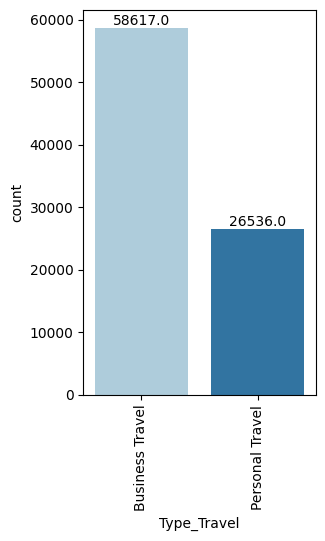

```python
labeled_barplot(data, 'Type_Travel')
```

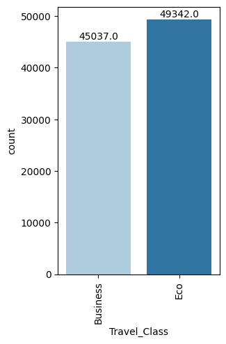

```python
labeled_barplot(data, 'Travel_Class')
```

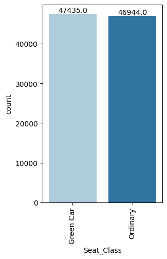

```python
labeled_barplot(data, 'Seat_Class')
```

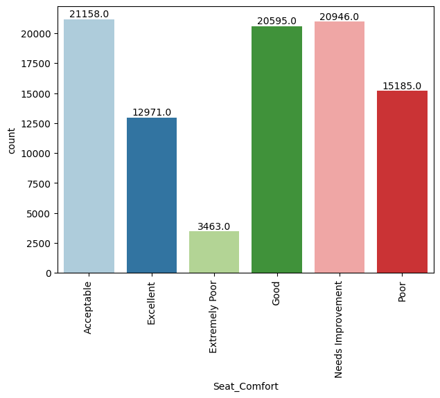

```python
labeled_barplot(data, 'Seat_Comfort')
```

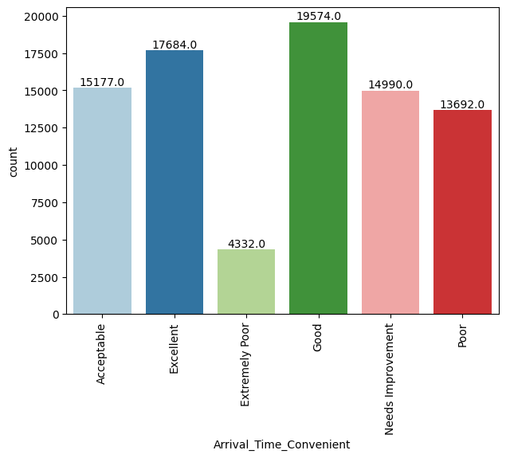

```python
labeled_barplot(data, 'Arrival_Time_Convenient')
```

## **Data Preprocessing**

```python
# there are some "categorical" and some "numerical" columns in this dataset:
categorical_columns   = ['Gender', 'Customer_Type', 'Type_Travel', 'Travel_Class', 'Seat_Class']
numerical_columns     = ['ID', 'Age', 'Travel_Distance', 'Departure_Delay_in_Mins', 'Arrival_Delay_in_Mins']
likert_scale_columns1 = ["Seat_Comfort", "Arrival_Time_Convenient", "Catering", "Onboard_Wifi_Service",
                        "Onboard_Entertainment", "Online_Support", "Ease_of_Online_Booking", "Onboard_Service", "Legroom",
                        "Baggage_Handling", "CheckIn_Service", "Cleanliness", "Online_Boarding"]
likert_scale_columns2 = ["Platform_Location"]
```

```python
def data_preprocessing(data):

  ###################  Missing Value Imputation  ###################

  ## Filling Missing values in categorical columns and likert-scale columns with "the most frequent value" in those columns.
  for column in categorical_columns + likert_scale_columns1 + likert_scale_columns2:
      data[column].fillna(value = data[column].mode()[0], inplace=True)

  ## Filling Missing values in numerical columns with "the mean" in those columns.
  for column in numerical_columns:
      data[column].fillna(value=data[column].mean(), inplace=True)


  ###################  Encoding Categorical Columns  ###################

  ### Do one hot encoding for categorical variables
  encoded_cols = pd.get_dummies(data[categorical_columns], prefix = categorical_columns)
  data = pd.concat([data, encoded_cols], axis=1)         # concatenate the encoded columns with the original dataframe
  data.drop(categorical_columns, axis=1, inplace=True)   # drop the original categorical columns


  ###################  Encoding Likert Scale Columns  ###################

  mapping1 = {'Extremely Poor': 1,    'Poor': 2,         'Acceptable': 3, 'Needs Improvement': 4, 'Good': 5,       'Excellent': 6      }
  mapping2 = {'Very Inconvenient': 1, 'Inconvenient': 2, 'Manageable': 3, 'Needs Improvement': 4, 'Convenient': 5, 'Very Convenient': 6}

  # Mapping Lekert scale texts to ordinal numbers
  ordinal_columns1 = data[likert_scale_columns1].applymap(lambda x: mapping1.get(x))
  ordinal_columns2 = data[likert_scale_columns2].applymap(lambda x: mapping2.get(x))

  # Dropping Likert-scale columns
  data = data.drop(likert_scale_columns1, axis = 1)
  data = data.drop(likert_scale_columns2, axis = 1)

  # Change column types from float to int
  for col in ordinal_columns1.columns:
    ordinal_columns1[col] = ordinal_columns1[col].astype(int)
  for col in ordinal_columns2.columns:
    ordinal_columns2[col] = ordinal_columns2[col].astype(int)

  # Adding Mapped columns (Containing Ordinal numbers instead of Likert Scale texts)
  data = pd.concat([data, ordinal_columns1], axis=1)
  data = pd.concat([data, ordinal_columns2], axis=1)

  return data
```

```python
# Creating metric function
def metrics_score(actual, predicted):

    print(classification_report(actual, predicted, digits=4))

    plt.figure(figsize=(4,3))

    sns.heatmap(confusion_matrix(actual, predicted),
                xticklabels=['False', 'True'],
                yticklabels=['False', 'True'],
                annot=True,
                fmt='.2f')

    plt.ylabel('Actual')
    plt.xlabel('Predicted')
    plt.show()
```

```python
# Separating Target Variable
X = data.drop(['Overall_Experience'], axis = 1)
Y = data[['Overall_Experience']]
```

```python
# Splitting the dataset into the Training and Evaluation set.
X_train, X_test, y_train, y_test = train_test_split(X, Y, test_size = 0.25, random_state = 42,stratify = Y)
```

```python
X_train = data_preprocessing(X_train)      # 75% of the dataset
X_test  = data_preprocessing(X_test)       # 25% of the dataset
```

```python
# "ID" column would not add any value to our analysis, so we can delete it.
X_train = X_train.drop(['ID'], axis = 1)
X_test  = X_test.drop( ['ID'], axis = 1)
```

**Let's check the correlation between variables**

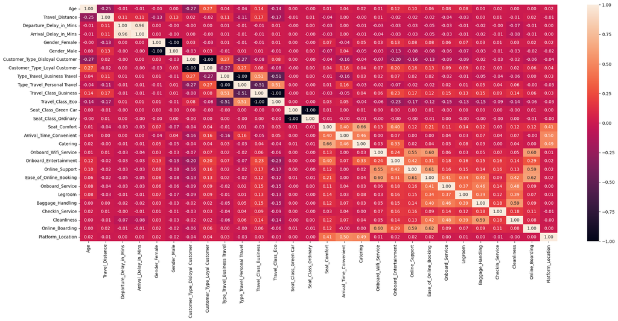

```python
plt.figure(figsize=(25,10))
sns.heatmap(X_train.corr(), annot=True, fmt='0.2f')
plt.show()
```

**Observations:**

- "Departure_Delay_in_Mins" and "Departure_Delay_in_Mins" are highly correlated (0.96). We can remove one of them from the data.

```python
X_train = X_train.drop(['Departure_Delay_in_Mins'], axis = 1)
X_test  = X_test.drop( ['Departure_Delay_in_Mins'], axis = 1)
```

#### **some models need to receive scaled/normalized data, so we keep a copy of normalized x_train and x_test.**

```python
scaler = MinMaxScaler(feature_range=(-1,1)).fit(X_train)

X_train_scaled = scaler.transform(X_train)
X_test_scaled  = scaler.transform(X_test)
```

# **Models**

## **Logistic Regression**

```
              precision    recall  f1-score   support

           0     0.7913    0.7765    0.7838     10697
           1     0.8175    0.8302    0.8238     12898

    accuracy                         0.8058     23595
   macro avg     0.8044    0.8033    0.8038     23595
weighted avg     0.8056    0.8058    0.8057     23595
```

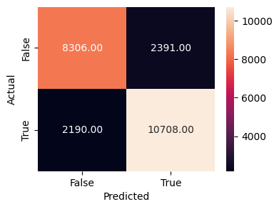

```python
lg = LogisticRegression()

# Train the model using the training set
lg.fit(X_train, y_train)

# Make predictions using the test set
y_pred = lg.predict(X_test)

metrics_score(y_test, y_pred)
```

### **SVM (Support Vector Machine)**

- #### Using **Linear** Kernel

```python
svm_linear = SVC(kernel='linear',probability=True)
svm_linear.fit(X = X_train_scaled, y = y_train)

y_pred_svmLinear = svm_linear.predict(X_test_scaled)
metrics_score(y_test, y_pred_svmLinear)
```

[output not shown]

- #### Using **RBF** Kernel

```python
svm_rbf = SVC(kernel='rbf',probability=True)
svm_rbf.fit(X_train_scaled, y_train)

y_pred_svmRBF = svm_rbf.predict(X_test_scaled)
metrics_score(y_test, y_pred_svmRBF)
```

[output not shown]

## **Decision Tree Classifier**

```
              precision    recall  f1-score   support

           0     0.9135    0.9251    0.9193     10697
           1     0.9372    0.9274    0.9323     12898

    accuracy                         0.9263     23595
   macro avg     0.9254    0.9262    0.9258     23595
weighted avg     0.9265    0.9263    0.9264     23595
```

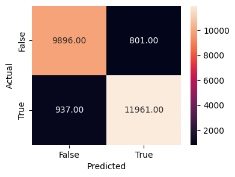

```python
model_dt = DecisionTreeClassifier(random_state = 1)
model_dt.fit(X_train, y_train)

y_pred_dt = model_dt.predict(X_test)
metrics_score(y_test, y_pred_dt)
```

## **Random Forest**

```
              precision    recall  f1-score   support

           0     0.9387    0.9519    0.9453     10697
           1     0.9597    0.9484    0.9540     12898

    accuracy                         0.9500     23595
   macro avg     0.9492    0.9502    0.9497     23595
weighted avg     0.9502    0.9500    0.9501     23595
```

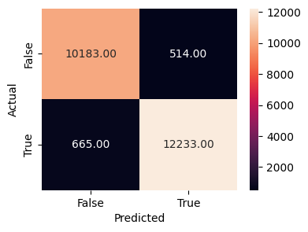

```python
rf_estimator = RandomForestClassifier(random_state=1)
rf_estimator.fit(X_train, y_train)

y_pred_rf = rf_estimator.predict(X_test)
metrics_score(y_test, y_pred_rf)
```

```python
# Finding The Most Important Features
feature_importances = rf_estimator.feature_importances_

columns = X_train.columns

importance_df = pd.DataFrame(feature_importances,
                             index=columns,
                             columns = ['Importance']).sort_values(by = 'Importance',
                             ascending = False)

importance_df.Importance
```

```
Onboard_Entertainment              0.171837
Seat_Comfort                       0.132039
Online_Support                     0.076062
Ease_of_Online_Booking             0.075586
Legroom                            0.043363
Catering                           0.036450
Travel_Distance                    0.036292
Age                                0.032729
Onboard_Service                    0.030840
Customer_Type_Disloyal Customer    0.028973
Baggage_Handling                   0.028265
Customer_Type_Loyal Customer       0.026016
Gender_Male                        0.025726
Cleanliness                        0.025092
Gender_Female                      0.024791
Online_Boarding                    0.024334
Travel_Class_Eco                   0.023223
CheckIn_Service                    0.022815
Travel_Class_Business              0.021960
Arrival_Time_Convenient            0.020645
Platform_Location                  0.019907
Arrival_Delay_in_Mins              0.019789
Type_Travel_Personal Travel        0.015804
Onboard_Wifi_Service               0.015402
Type_Travel_Business Travel        0.014381
Seat_Class_Ordinary                0.003856
Seat_Class_Green Car               0.003824
Name: Importance, dtype: float64
```

**Most important features are "onboard_Entertainment" and "Seat_comfort"**

## **Deep Learning**

#### **Model 1**

```python
# Fixing the seed for random number generators
np.random.seed(42)
random.seed(42)
tf.random.set_seed(42)
```

```python
model_1 = Sequential()
model_1.add(Dense(128, activation='relu', input_shape=(X_train.shape[1],)))
model_1.add(Dropout(0.2))
model_1.add(Dense(64, activation='relu'))
model_1.add(Dropout(0.1))
model_1.add(Dense(1, activation='sigmoid'))
```

```python
model_1.compile(loss = 'binary_crossentropy', optimizer='adamax', metrics=['accuracy'])
```

```python
# training the model
history_1 = model_1.fit(X_train_scaled,
                    y_train,
                    validation_split = 0.1,
                    epochs = 100,
                    verbose = 2)
```

```
1991/1991 - 11s - loss: 0.1294 - accuracy: 0.9442 - val_loss: 0.1334 - val_accuracy: 0.9436 - 11s/epoch - 6ms/step
1991/1991 - 5s - loss: 0.1284 - accuracy: 0.9448 - val_loss: 0.1313 - val_accuracy: 0.9431 - 5s/epoch - 2ms/step
1991/1991 - 6s - loss: 0.1289 - accuracy: 0.9441 - val_loss: 0.1326 - val_accuracy: 0.9442 - 6s/epoch - 3ms/step
1991/1991 - 5s - loss: 0.1282 - accuracy: 0.9445 - val_loss: 0.1306 - val_accuracy: 0.9441 - 5s/epoch - 3ms/step
1991/1991 - 4s - loss: 0.1275 - accuracy: 0.9438 - val_loss: 0.1310 - val_accuracy: 0.9450 - 4s/epoch - 2ms/step
1991/1991 - 4s - loss: 0.1285 - accuracy: 0.9453 - val_loss: 0.1300 - val_accuracy: 0.9429 - 4s/epoch - 2ms/step
1991/1991 - 5s - loss: 0.1259 - accuracy: 0.9453 - val_loss: 0.1308 - val_accuracy: 0.9443 - 5s/epoch - 3ms/step
1991/1991 - 7s - loss: 0.1259 - accuracy: 0.9451 - val_loss: 0.1305 - val_accuracy: 0.9439 - 7s/epoch - 3ms/step
1991/1991 - 5s - loss: 0.1245 - accuracy: 0.9457 - val_loss: 0.1287 - val_accuracy: 0.9453 - 5s/epoch - 2ms/step
1991/1991 - 5s - loss: 0.1250 - accuracy: 0.9454 - val_loss: 0.1283 - val_accuracy: 0.9449 - 5s/epoch - 3ms/step
1991/1991 - 4s - loss: 0.1243 - accuracy: 0.9466 - val_loss: 0.1298 - val_accuracy: 0.9429 - 4s/epoch - 2ms/step
1991/1991 - 4s - loss: 0.1236 - accuracy: 0.9460 - val_loss: 0.1288 - val_accuracy: 0.9439 - 4s/epoch - 2ms/step
1991/1991 - 5s - loss: 0.1229 - accuracy: 0.9468 - val_loss: 0.1287 - val_accuracy: 0.9441 - 5s/epoch - 2ms/step
1991/1991 - 4s - loss: 0.1243 - accuracy: 0.9459 - val_loss: 0.1282 - val_accuracy: 0.9435 - 4s/epoch - 2ms/step
1991/1991 - 4s - loss: 0.1223 - accuracy: 0.9462 - val_loss: 0.1276 - val_accuracy: 0.9443 - 4s/epoch - 2ms/step
1991/1991 - 4s - loss: 0.1216 - accuracy: 0.9472 - val_loss: 0.1275 - val_accuracy: 0.9442 - 4s/epoch - 2ms/step
1991/1991 - 5s - loss: 0.1215 - accuracy: 0.9474 - val_loss: 0.1276 - val_accuracy: 0.9434 - 5s/epoch - 2ms/step
1991/1991 - 4s - loss: 0.1199 - accuracy: 0.9479 - val_loss: 0.1265 - val_accuracy: 0.9458 - 4s/epoch - 2ms/step
1991/1991 - 4s - loss: 0.1207 - accuracy: 0.9483 - val_loss: 0.1268 - val_accuracy: 0.9462 - 4s/epoch - 2ms/step
1991/1991 - 7s - loss: 0.1215 - accuracy: 0.9473 - val_loss: 0.1272 - val_accuracy: 0.9443 - 7s/epoch - 3ms/step
1991/1991 - 5s - loss: 0.1194 - accuracy: 0.9481 - val_loss: 0.1275 - val_accuracy: 0.9429 - 5s/epoch - 2ms/step
1991/1991 - 7s - loss: 0.1190 - accuracy: 0.9481 - val_loss: 0.1264 - val_accuracy: 0.9456 - 7s/epoch - 3ms/step
1991/1991 - 7s - loss: 0.1191 - accuracy: 0.9481 - val_loss: 0.1261 - val_accuracy: 0.9448 - 7s/epoch - 3ms/step
1991/1991 - 4s - loss: 0.1190 - accuracy: 0.9479 - val_loss: 0.1263 - val_accuracy: 0.9463 - 4s/epoch - 2ms/step
1991/1991 - 5s - loss: 0.1171 - accuracy: 0.9489 - val_loss: 0.1257 - val_accuracy: 0.9459 - 5s/epoch - 3ms/step
1991/1991 - 4s - loss: 0.1170 - accuracy: 0.9485 - val_loss: 0.1258 - val_accuracy: 0.9458 - 4s/epoch - 2ms/step
1991/1991 - 4s - loss: 0.1165 - accuracy: 0.9492 - val_loss: 0.1252 - val_accuracy: 0.9460 - 4s/epoch - 2ms/step
1991/1991 - 7s - loss: 0.1173 - accuracy: 0.9486 - val_loss: 0.1257 - val_accuracy: 0.9438 - 7s/epoch - 4ms/step
1991/1991 - 4s - loss: 0.1162 - accuracy: 0.9494 - val_loss: 0.1242 - val_accuracy: 0.9443 - 4s/epoch - 2ms/step
1991/1991 - 4s - loss: 0.1174 - accuracy: 0.9492 - val_loss: 0.1248 - val_accuracy: 0.9452 - 4s/epoch - 2ms/step
1991/1991 - 5s - loss: 0.1161 - accuracy: 0.9493 - val_loss: 0.1262 - val_accuracy: 0.9453 - 5s/epoch - 3ms/step
1991/1991 - 4s - loss: 0.1152 - accuracy: 0.9501 - val_loss: 0.1261 - val_accuracy: 0.9453 - 4s/epoch - 2ms/step
1991/1991 - 4s - loss: 0.1163 - accuracy: 0.9493 - val_loss: 0.1262 - val_accuracy: 0.9463 - 4s/epoch - 2ms/step
1991/1991 - 5s - loss: 0.1152 - accuracy: 0.9492 - val_loss: 0.1250 - val_accuracy: 0.9455 - 5s/epoch - 2ms/step
1991/1991 - 4s - loss: 0.1154 - accuracy: 0.9498 - val_loss: 0.1246 - val_accuracy: 0.9453 - 4s/epoch - 2ms/step
1991/1991 - 4s - loss: 0.1144 - accuracy: 0.9503 - val_loss: 0.1243 - val_accuracy: 0.9467 - 4s/epoch - 2ms/step
1991/1991 - 4s - loss: 0.1140 - accuracy: 0.9503 - val_loss: 0.1247 - val_accuracy: 0.9453 - 4s/epoch - 2ms/step
1991/1991 - 5s - loss: 0.1134 - accuracy: 0.9503 - val_loss: 0.1236 - val_accuracy: 0.9463 - 5s/epoch - 3ms/step
1991/1991 - 4s - loss: 0.1146 - accuracy: 0.9500 - val_loss: 0.1250 - val_accuracy: 0.9456 - 4s/epoch - 2ms/step
1991/1991 - 5s - loss: 0.1137 - accuracy: 0.9504 - val_loss: 0.1238 - val_accuracy: 0.9448 - 5s/epoch - 3ms/step
```

[output cut: 45 more lines]

```
1991/1991 - 8s - loss: 0.1039 - accuracy: 0.9540 - val_loss: 0.1223 - val_accuracy: 0.9486 - 8s/epoch - 4ms/step
1991/1991 - 4s - loss: 0.1041 - accuracy: 0.9547 - val_loss: 0.1224 - val_accuracy: 0.9470 - 4s/epoch - 2ms/step
1991/1991 - 4s - loss: 0.1033 - accuracy: 0.9549 - val_loss: 0.1205 - val_accuracy: 0.9489 - 4s/epoch - 2ms/step
1991/1991 - 5s - loss: 0.1046 - accuracy: 0.9539 - val_loss: 0.1202 - val_accuracy: 0.9482 - 5s/epoch - 2ms/step
1991/1991 - 4s - loss: 0.1056 - accuracy: 0.9536 - val_loss: 0.1213 - val_accuracy: 0.9484 - 4s/epoch - 2ms/step
1991/1991 - 4s - loss: 0.1047 - accuracy: 0.9542 - val_loss: 0.1215 - val_accuracy: 0.9476 - 4s/epoch - 2ms/step
1991/1991 - 5s - loss: 0.1040 - accuracy: 0.9549 - val_loss: 0.1208 - val_accuracy: 0.9472 - 5s/epoch - 3ms/step
1991/1991 - 4s - loss: 0.1049 - accuracy: 0.9540 - val_loss: 0.1216 - val_accuracy: 0.9486 - 4s/epoch - 2ms/step
1991/1991 - 4s - loss: 0.1040 - accuracy: 0.9544 - val_loss: 0.1193 - val_accuracy: 0.9483 - 4s/epoch - 2ms/step
1991/1991 - 4s - loss: 0.1039 - accuracy: 0.9551 - val_loss: 0.1202 - val_accuracy: 0.9470 - 4s/epoch - 2ms/step
1991/1991 - 5s - loss: 0.1045 - accuracy: 0.9542 - val_loss: 0.1199 - val_accuracy: 0.9480 - 5s/epoch - 2ms/step
1991/1991 - 4s - loss: 0.1022 - accuracy: 0.9557 - val_loss: 0.1204 - val_accuracy: 0.9487 - 4s/epoch - 2ms/step
1991/1991 - 4s - loss: 0.1035 - accuracy: 0.9550 - val_loss: 0.1207 - val_accuracy: 0.9477 - 4s/epoch - 2ms/step
1991/1991 - 5s - loss: 0.1031 - accuracy: 0.9547 - val_loss: 0.1200 - val_accuracy: 0.9496 - 5s/epoch - 3ms/step
1991/1991 - 4s - loss: 0.1035 - accuracy: 0.9546 - val_loss: 0.1196 - val_accuracy: 0.9477 - 4s/epoch - 2ms/step
```

```
              precision    recall  f1-score   support

           0     0.9301    0.9577    0.9437     10697
           1     0.9641    0.9403    0.9520     12898

    accuracy                         0.9482     23595
   macro avg     0.9471    0.9490    0.9479     23595
weighted avg     0.9487    0.9482    0.9483     23595
```

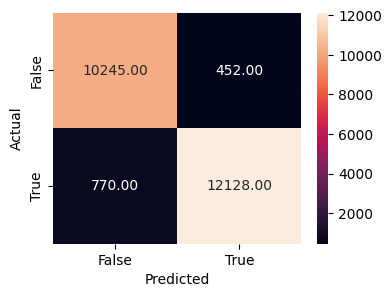

```python
### Model evaluation on the test data
model_1.evaluate(X_test_scaled, y_test, verbose = 1)
y_pred_deep_model1 = np.round(model_1.predict(X_test_scaled))
metrics_score(y_test, y_pred_deep_model1)
```

### **Model 2**

```python
# Clearing the backend
backend.clear_session()
```

```python
# Fixing the seed for random number generators
np.random.seed(42)
random.seed(42)
tf.random.set_seed(42)
```

```python
# added more layers, more neurons in each layer, changed the activation function
model_2 = Sequential()
model_2.add(Dense(256, activation='tanh', input_shape=(X_train.shape[1],)))
model_2.add(Dropout(0.1))
model_2.add(Dense(128, activation='tanh'))
model_2.add(Dropout(0.1))
model_2.add(Dense(64, activation='tanh'))
model_2.add(Dropout(0.1))
model_2.add(Dense(32, activation='tanh'))
model_2.add(Dense(1, activation='sigmoid'))
```

```python
model_2.compile(loss = 'binary_crossentropy', optimizer=tf.keras.optimizers.Adam(learning_rate=0.001), metrics=['accuracy'])
```

```python
history_2 = model_2.fit(X_train_scaled,
                    y_train,
                    validation_split=0.1,
                    epochs=200,
                    verbose=2)
```

```
1991/1991 - 9s - loss: 0.2685 - accuracy: 0.8889 - val_loss: 0.1972 - val_accuracy: 0.9193 - 9s/epoch - 4ms/step
1991/1991 - 6s - loss: 0.1884 - accuracy: 0.9221 - val_loss: 0.1623 - val_accuracy: 0.9323 - 6s/epoch - 3ms/step
1991/1991 - 7s - loss: 0.1721 - accuracy: 0.9276 - val_loss: 0.1720 - val_accuracy: 0.9322 - 7s/epoch - 4ms/step
1991/1991 - 6s - loss: 0.1634 - accuracy: 0.9315 - val_loss: 0.1745 - val_accuracy: 0.9295 - 6s/epoch - 3ms/step
1991/1991 - 6s - loss: 0.1571 - accuracy: 0.9337 - val_loss: 0.1532 - val_accuracy: 0.9353 - 6s/epoch - 3ms/step
1991/1991 - 7s - loss: 0.1538 - accuracy: 0.9342 - val_loss: 0.1488 - val_accuracy: 0.9353 - 7s/epoch - 3ms/step
1991/1991 - 6s - loss: 0.1533 - accuracy: 0.9344 - val_loss: 0.1637 - val_accuracy: 0.9326 - 6s/epoch - 3ms/step
1991/1991 - 7s - loss: 0.1483 - accuracy: 0.9364 - val_loss: 0.1491 - val_accuracy: 0.9361 - 7s/epoch - 4ms/step
1991/1991 - 5s - loss: 0.1484 - accuracy: 0.9366 - val_loss: 0.1501 - val_accuracy: 0.9390 - 5s/epoch - 3ms/step
1991/1991 - 7s - loss: 0.1441 - accuracy: 0.9387 - val_loss: 0.1455 - val_accuracy: 0.9381 - 7s/epoch - 4ms/step
1991/1991 - 6s - loss: 0.1428 - accuracy: 0.9387 - val_loss: 0.1458 - val_accuracy: 0.9373 - 6s/epoch - 3ms/step
1991/1991 - 7s - loss: 0.1412 - accuracy: 0.9398 - val_loss: 0.1405 - val_accuracy: 0.9407 - 7s/epoch - 4ms/step
1991/1991 - 7s - loss: 0.1390 - accuracy: 0.9398 - val_loss: 0.1431 - val_accuracy: 0.9390 - 7s/epoch - 3ms/step
1991/1991 - 7s - loss: 0.1398 - accuracy: 0.9405 - val_loss: 0.1420 - val_accuracy: 0.9405 - 7s/epoch - 4ms/step
1991/1991 - 5s - loss: 0.1372 - accuracy: 0.9407 - val_loss: 0.1404 - val_accuracy: 0.9395 - 5s/epoch - 3ms/step
1991/1991 - 7s - loss: 0.1365 - accuracy: 0.9411 - val_loss: 0.1393 - val_accuracy: 0.9400 - 7s/epoch - 4ms/step
1991/1991 - 6s - loss: 0.1354 - accuracy: 0.9410 - val_loss: 0.1413 - val_accuracy: 0.9384 - 6s/epoch - 3ms/step
1991/1991 - 6s - loss: 0.1344 - accuracy: 0.9414 - val_loss: 0.1360 - val_accuracy: 0.9412 - 6s/epoch - 3ms/step
1991/1991 - 9s - loss: 0.1332 - accuracy: 0.9420 - val_loss: 0.1349 - val_accuracy: 0.9394 - 9s/epoch - 5ms/step
1991/1991 - 7s - loss: 0.1325 - accuracy: 0.9428 - val_loss: 0.1384 - val_accuracy: 0.9412 - 7s/epoch - 3ms/step
1991/1991 - 8s - loss: 0.1314 - accuracy: 0.9435 - val_loss: 0.1388 - val_accuracy: 0.9397 - 8s/epoch - 4ms/step
1991/1991 - 8s - loss: 0.1317 - accuracy: 0.9426 - val_loss: 0.1364 - val_accuracy: 0.9410 - 8s/epoch - 4ms/step
1991/1991 - 7s - loss: 0.1295 - accuracy: 0.9432 - val_loss: 0.1362 - val_accuracy: 0.9410 - 7s/epoch - 3ms/step
1991/1991 - 6s - loss: 0.1305 - accuracy: 0.9433 - val_loss: 0.1354 - val_accuracy: 0.9421 - 6s/epoch - 3ms/step
1991/1991 - 6s - loss: 0.1290 - accuracy: 0.9433 - val_loss: 0.1371 - val_accuracy: 0.9386 - 6s/epoch - 3ms/step
1991/1991 - 5s - loss: 0.1286 - accuracy: 0.9434 - val_loss: 0.1351 - val_accuracy: 0.9405 - 5s/epoch - 3ms/step
1991/1991 - 7s - loss: 0.1272 - accuracy: 0.9445 - val_loss: 0.1345 - val_accuracy: 0.9405 - 7s/epoch - 4ms/step
1991/1991 - 5s - loss: 0.1256 - accuracy: 0.9450 - val_loss: 0.1394 - val_accuracy: 0.9407 - 5s/epoch - 3ms/step
1991/1991 - 8s - loss: 0.1252 - accuracy: 0.9450 - val_loss: 0.1340 - val_accuracy: 0.9424 - 8s/epoch - 4ms/step
1991/1991 - 5s - loss: 0.1269 - accuracy: 0.9452 - val_loss: 0.1380 - val_accuracy: 0.9415 - 5s/epoch - 3ms/step
1991/1991 - 6s - loss: 0.1250 - accuracy: 0.9454 - val_loss: 0.1342 - val_accuracy: 0.9408 - 6s/epoch - 3ms/step
1991/1991 - 6s - loss: 0.1249 - accuracy: 0.9451 - val_loss: 0.1359 - val_accuracy: 0.9417 - 6s/epoch - 3ms/step
1991/1991 - 5s - loss: 0.1239 - accuracy: 0.9461 - val_loss: 0.1371 - val_accuracy: 0.9414 - 5s/epoch - 3ms/step
1991/1991 - 7s - loss: 0.1242 - accuracy: 0.9463 - val_loss: 0.1345 - val_accuracy: 0.9407 - 7s/epoch - 4ms/step
1991/1991 - 5s - loss: 0.1227 - accuracy: 0.9465 - val_loss: 0.1349 - val_accuracy: 0.9424 - 5s/epoch - 3ms/step
1991/1991 - 7s - loss: 0.1239 - accuracy: 0.9467 - val_loss: 0.1357 - val_accuracy: 0.9408 - 7s/epoch - 3ms/step
1991/1991 - 5s - loss: 0.1235 - accuracy: 0.9460 - val_loss: 0.1320 - val_accuracy: 0.9441 - 5s/epoch - 3ms/step
1991/1991 - 8s - loss: 0.1224 - accuracy: 0.9468 - val_loss: 0.1327 - val_accuracy: 0.9425 - 8s/epoch - 4ms/step
1991/1991 - 6s - loss: 0.1227 - accuracy: 0.9462 - val_loss: 0.1342 - val_accuracy: 0.9435 - 6s/epoch - 3ms/step
1991/1991 - 6s - loss: 0.1225 - accuracy: 0.9458 - val_loss: 0.1325 - val_accuracy: 0.9425 - 6s/epoch - 3ms/step
```

[output cut: 145 more lines]

```
1991/1991 - 5s - loss: 0.1003 - accuracy: 0.9561 - val_loss: 0.1317 - val_accuracy: 0.9438 - 5s/epoch - 3ms/step
1991/1991 - 7s - loss: 0.0996 - accuracy: 0.9570 - val_loss: 0.1372 - val_accuracy: 0.9441 - 7s/epoch - 3ms/step
1991/1991 - 5s - loss: 0.1000 - accuracy: 0.9563 - val_loss: 0.1356 - val_accuracy: 0.9425 - 5s/epoch - 3ms/step
1991/1991 - 5s - loss: 0.0992 - accuracy: 0.9571 - val_loss: 0.1377 - val_accuracy: 0.9436 - 5s/epoch - 3ms/step
1991/1991 - 7s - loss: 0.0993 - accuracy: 0.9568 - val_loss: 0.1364 - val_accuracy: 0.9442 - 7s/epoch - 3ms/step
1991/1991 - 5s - loss: 0.0989 - accuracy: 0.9566 - val_loss: 0.1335 - val_accuracy: 0.9425 - 5s/epoch - 3ms/step
1991/1991 - 7s - loss: 0.1002 - accuracy: 0.9566 - val_loss: 0.1336 - val_accuracy: 0.9459 - 7s/epoch - 3ms/step
1991/1991 - 6s - loss: 0.0993 - accuracy: 0.9573 - val_loss: 0.1348 - val_accuracy: 0.9442 - 6s/epoch - 3ms/step
1991/1991 - 9s - loss: 0.0993 - accuracy: 0.9564 - val_loss: 0.1363 - val_accuracy: 0.9439 - 9s/epoch - 5ms/step
1991/1991 - 5s - loss: 0.0987 - accuracy: 0.9573 - val_loss: 0.1345 - val_accuracy: 0.9459 - 5s/epoch - 3ms/step
1991/1991 - 6s - loss: 0.0995 - accuracy: 0.9566 - val_loss: 0.1372 - val_accuracy: 0.9411 - 6s/epoch - 3ms/step
1991/1991 - 6s - loss: 0.0977 - accuracy: 0.9571 - val_loss: 0.1332 - val_accuracy: 0.9450 - 6s/epoch - 3ms/step
1991/1991 - 5s - loss: 0.0986 - accuracy: 0.9575 - val_loss: 0.1416 - val_accuracy: 0.9459 - 5s/epoch - 3ms/step
1991/1991 - 7s - loss: 0.0987 - accuracy: 0.9573 - val_loss: 0.1338 - val_accuracy: 0.9429 - 7s/epoch - 3ms/step
1991/1991 - 5s - loss: 0.0983 - accuracy: 0.9578 - val_loss: 0.1364 - val_accuracy: 0.9436 - 5s/epoch - 3ms/step
```

#### **Accuracy vs Epoch Graph:**

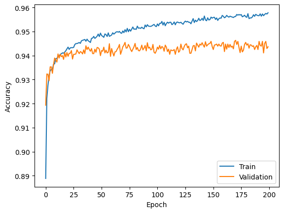

```python
plt.plot(history_2.history['accuracy'])
plt.plot(history_2.history['val_accuracy'])

plt.ylabel('Accuracy')
plt.xlabel('Epoch')

plt.legend(['Train', 'Validation'], loc='lower right')
plt.show()
```

- The training accuracy has been increasing with the increase in the epochs.
- The validation accuracy is almost constant between epoches 25 to 200.
- The train and validation accuracy have been moving apart witht hte increase in epoches which is an indicator of overfitting.

```
              precision    recall  f1-score   support

           0     0.9281    0.9551    0.9414     10697
           1     0.9619    0.9386    0.9501     12898

    accuracy                         0.9461     23595
   macro avg     0.9450    0.9469    0.9457     23595
weighted avg     0.9465    0.9461    0.9461     23595
```

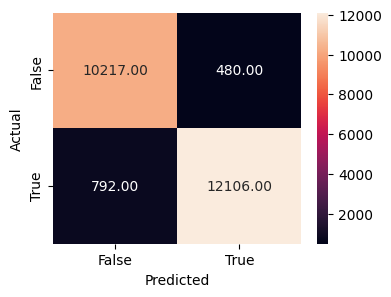

```python
### Model evaluation on the test data
model_2.evaluate(X_test_scaled, y_test, verbose = 1)
y_pred_deep_model2 = np.round(model_2.predict(X_test_scaled))
metrics_score(y_test, y_pred_deep_model2)
```

### **XGBoost**

```
              precision    recall  f1-score   support

           0     0.9409    0.9534    0.9471     10697
           1     0.9609    0.9504    0.9556     12898

    accuracy                         0.9517     23595
   macro avg     0.9509    0.9519    0.9514     23595
weighted avg     0.9518    0.9517    0.9518     23595
```

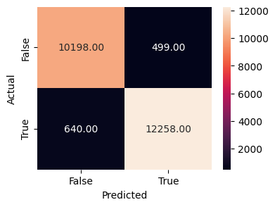

```python
# Define the XGBoost classifier
model_xgb = xgb.XGBClassifier(objective='binary:logistic', random_state=42)

# Train the classifier on the training data
model_xgb.fit(X_train, y_train)

# predictions on the test data
y_pred_xgb = model_xgb.predict(X_test)

# Evaluate the accuracy of the classifier
metrics_score(y_test, y_pred_xgb)
```

**Hyperparameter Tuning**

```
Best hyperparameters: {'learning_rate': 0.1, 'max_depth': 10, 'n_estimators': 200}
Accuracy: 0.9525598701662819
              precision    recall  f1-score   support

           0     0.9424    0.9605    0.9513     10697
           1     0.9667    0.9513    0.9589     12898

    accuracy                         0.9555     23595
   macro avg     0.9545    0.9559    0.9551     23595
weighted avg     0.9557    0.9555    0.9555     23595
```

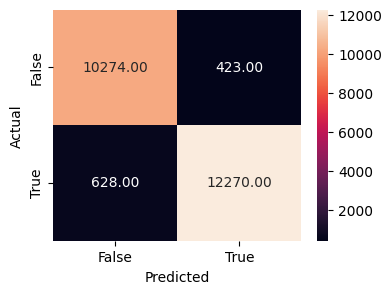

```python
# Hyperparameter tuning for X_train/X_eval data
model_xgb3 = xgb.XGBClassifier(objective='binary:logistic', random_state=42)

# Define the hyperparameter grid
param_grid = {
    'max_depth': [5, 10, 15],
    'learning_rate': [0.1, 0.01, 0.001],
    'n_estimators': [50, 100, 200],
}

# Perform grid search cross-validation
grid_search = GridSearchCV(
    model_xgb3, param_grid=param_grid, cv=5, scoring='accuracy', n_jobs=-1
)
grid_search.fit(X_train, y_train, verbose = 2)

# Print the best hyperparameters and accuracy score
print("Best hyperparameters:", grid_search.best_params_)
print("Accuracy:", grid_search.best_score_)

# Evaluate the best model on the testing data
best_model = grid_search.best_estimator_
y_pred_xgb3 = best_model.predict(X_test)
metrics_score(y_test, y_pred_xgb3)
```

#### **Conclusion**

- Many Models were tested including:
  - Logistic Regression,
  - Decision Tree,
  - Random Forest,
  - XGBoost
  - Support Vector Machine,
  - Neural Network
- The best results were achieved using **XGBoost** algorithm with these parameters: **learning_rate: 0.1, max_depth: 10, n_estimators: 200**
- The best results after XGBoost was earned using **Random Forest** model.
- Here is the comparison between the accuracy of these models:

| Model | Accuracy |
| --- | --- |
| Logistic Regression | 0.8058 |
| Decision Tree | 0.9263 |
| Random Forest | 0.9500 |
| Neural Network model_1 | 0.9482 |
| Neural Network model_2 | 0.9461 |
| XGBoost | 0.9517 |
| XGBoost after hyperparameter tuning | 0.9555 |